# Predicting the ATTACK Values for LeBron James

##### Exponential Smoothing Model

Next, let’s find an ARMA model for the exponential smoothing model. Below are the plots of the residuals, as well as the ACF and PACF plots for the residuals.

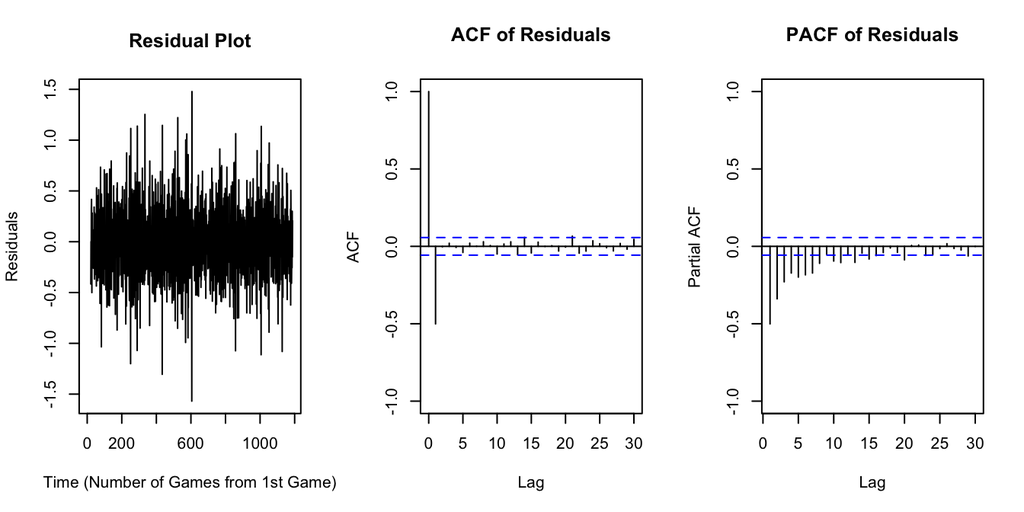

Figure 7: Residual Plot of Exponential Smoothing Model and the ACF and PACF Plots of the Residuals

###### **Exponential Smoothing with MA(1)**

If we look at the ACF and PACF plots for the residuals of the exponential smoothing model in Figure 7, there is a single spike at lag 1 in the ACF plot and exponentially decreasing PACF values in the PACF plot. This information would suggest that we should use a **ARMA(p=0,q=1) or MA(1)** model. In Figure 8, we can see the MA(1) model’s theoretical ACF and PACF values in the red triangles laid over the sample ACF/PACF values generated by the residuals of the exponential smoothing model. The theoretical values are very accurate and close to the sample values, so this would indicate that an MA(1) model would be a good ARMA model fit.

###### **Exponential Smoothing with ARMA(1,1)**

For the second ARMA model, I chose to use the auto arima function once again to determine the best model. The auto.arima function will (similarly to the differencing model) select a model by minimizing conditional sum of squares. The auto.arima function returned the **ARMA(p=1,q=1)** model. In Figure 8 we can also see the ARMA(1,1) model shows identical theoretical ACF and PACF values to the MA(1) model, with the theoretical values overlaid as blue cirlces. Since the two ACF/PACF plots look the same, we can conclude that both the MA(1) and ARMA(1,1) are both good fits and will most likely yield similar results.

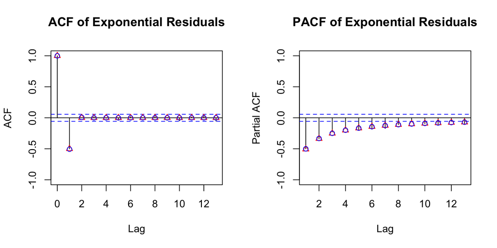

Figure 8: Sample ACF and PACF Plots with Theoretical Autocorrelations Overlay for MA(1) in red triangles and ARMA(1,1) in blue circles